# Rule transfer in biomedical event extraction

Event Extraction is concerned with identifying the relationship between entities.

The majority of events in the biomedical domain are biochemical reactions involving one or more participants, typically in an `agent`-`patient` construction.

Pattern-based rules for identifying textual mentions of such events can be generated automatically by extracting the shortest syntactic dependency path between known predicate-argument pairs.

This work examines the effects of applying rules generated for one event to a set of related events for which annotations are unavailable or incomplete.

## Questions to be answered

- **Are a class of semantically related events necessarily syntactically similar?**
  - Can we use patterns describing variations of the syntactic structure of one event to generalize rules for a class of related events?
  - How might one use knowledge of one event (i.e. the information encoded in a rule, including # of args, their semantic types, etc) to bootstrap a grammar for another (sparsely represented) event?
- **Is there a simple predictive model to estimate performance on transfer (ex. is it a function of path length, the final hop in the path, etc)?**
- How is path transfer related to trigger (predicate) diversity?
- How should rules be combined for $n$-ary events?
  - This might be out of the scope of this work...

### Exploring the Data

- After extracting syntactic depedency paths between `predicate` $\leftrightarrow$ `argument` pairs for each event type...
  - How much overlap do we see in the syntactic paths across events?
    - This is a direct measure over training data extractions
  - How much independence exists in these syntactic paths?
    - Are some unique to a specific event?
    - This is related to how rules should be combined for $n$-ary events

# Background

## Rules

The rules used in this work follow Odin-style rules (http://www.anthology.aclweb.org/P/P15/P15-4.pdf#page=139). Event rules are composed of some predicate (i.e. `trigger`) consisting of one or more tokens. Rules can be specified as a pattern over tokens or a pattern of syntactic dependencies. The output of a rule is a textual *mention*, a labeled collection of text spans.

### Event rules

Rules for events specify predicates (i.e. triggers) using a token pattern. These tokens may be specified as a regular expression over any combination of the raw text, lemma, or PoS tag attibutes of the token.

An event rule may describe each of its arguments as a syntactic dependency path originating from the predicate.  
Syntactic dependencies describe syntactic `head` $\leftrightarrow$ `dependent` relationships between words. Hops are directed, pointing from `head` to `dependent`. Patterns may follow hops in whichever direction is desired (`head` $\rightarrow$ `dependent` vs `dependent` $\rightarrow$ `head`). Each "hop" in the path leads to a word which may be constrained to varying degrees of lexicalization using a token pattern (described previously).

Each argument has a semantic type (ex. `Protein` vs `Gene`) and can consist of multiple tokens.

### A note about event extraction

For this work, the entities (i.e. mentions that can serve as event arguments) are provided to us. In event extraction, our focus is only the relationship/interaction between entities (or other events).

# Formulations

## Trigger relevance to an event

I will define the relevance of a trigger $t_i$ to an event $e$ as its normalized frequency within that event category:

$Rel(t_i,e) = \frac{f(t_i,e)}{\sum_{j}f(t_j,e)}$

where $f(t_i,e)$ is the frequency of trigger $t_i$ for the event $e$

## Relevance of a rule to an event

The relevance of a rule ($r$) for an event ($e$) should be a function of the relevance of a trigger ($t$) to $e$, the valency of the event ($v_e$), and the frequency of a rule ($r_f$):

$Rel(r, e) \approx f(Rel(t,e), v_e, r_f)$

## Alternative formulation

Of the occurrences of argument for event ($a_{e}$), what percentage is covered by rule $r$?

$Rel(r, e) \approx \frac{r_{f}}{a_{e}}$

## TODO: How common is a `(trigger PoS) + path + arg` to an event vs. to all events?

## TODO: Value of `(path | arg)` vs. `(path | trigger's PoS)`

# Experiment

### Main idea

Take the most frequent event in training, extract paths (rules), and apply those rules to other events.

### Details

Annotated corpora exist for identifying an event’s trigger (i.e. predicate) and its arguments.  
In this work, I’m going to focus on a class of events defined in the BioNLP 2009 GE task (i.e. Simple Events). This data is divided into three partitions: training, development, and testing.

From the training data, I will generate rules for the most commmon event and apapt those rules to a set of related events by substituting an appropriate predicate for each event while leaving the syntactic path unmodified:

#### Extracted Rule

```
label: Phosphorylation
pattern: |
  trigger=[lemma='phosphorylation']
  Theme:Protein >prep_of
```

#### Adapted Rule

```
label: Ubiquitination
pattern: |
  # the trigger has been changed
  trigger=[lemma='ubiquitination']
  Theme:Protein >prep_of
```

In this work, I will attempt to use wholly *unlexicalized* paths for event arguments meaning that each hop in the path is unconstrained in terms of the identity of the word:

### Lexicalized path

This **lexicalized** path originating from the predicate **ate** points to "Ayu" in the sentence: "**Ayu**'s cats **ate** the lizard."

```
>nsubj [lemma=cat] >poss [tag=NNP]
```

### Unlexicalized path

This **unlexicalized** path originating from the predicate **ate** points to "Ayu" in the sentence: "**Ayu**'s cats **ate** the lizard."

```
>nsubj >poss
```

## Evaluation

These rules will be evaluated against the development data. I will compare performance of the adapted rules on the development partition with a baseline measure where for each event, rules are extracted in the training data and then applied to all instances of that corresponding event in the development data.

| Experiments | Baseline |
| --- | --- |
| rules for `Event A` appled to `Event B` | rules for `Event B` applied to `Event B` |
| rules for `Event A` appled to `Event C` | rules for `Event C` applied to `Event C` |

## Getting started

```python
%matplotlib inline
import matplotlib.pylab as pylab
pylab.rcParams['figure.figsize'] = 15, 5
```

```python
# Shell commands

!echo "Number of rules extracted from training: `grep -c "\- name:" generated_rules.yml`"
```

```
Number of rules extracted from training: 4666
```

## Defining the `EventRule` class

```python
from collections import defaultdict, Counter
import re
import numpy as np
import pandas as pd
pd.set_option('display.mpl_style', 'default') # Make the graphs a bit prettier


class EventRule(object):
    def __init__(self, rule_string):
        assert("trigger = " in rule_string)
        # find trigger, args, and hops
        self._process_rule(rule_string)
        # TODO: estimate rule contribution to Class c
        self.score = None

    def remove_whitespace(self, text):
        return re.sub(r"\s+", "", text)

    def _process_rule(self, rule_string):
        # find label
        label = re.search("label:\s*(?P<label>.*)", rule_string)
        # find count
        cnt = re.search("count:\s*(?P<count>.*)", rule_string)
        # find pattern
        pattern = re.findall("pattern: [|]\n\s*(.*)", rule_string, re.DOTALL | re.MULTILINE)[0]
        pattern = re.sub("\s+", " ", pattern).strip()
        m = re.search("(?P<trigger>^.*?(\s*\[.*?\])+)\s+(?P<argname>.*?(?=:)):(?P<argtype>.*?\s)\s*=\s(?P<path>.*)", pattern)
        self.trigger = m.group("trigger").strip()
        # attempt to extract trigger tags
        tt = re.findall("tag=(?P<tag>[^\s\]]+)", self.trigger)
        self.trigger_tags = [t.strip() for t in tt]
        # remove whitespace in label
        self.label = self.remove_whitespace(label.group("label"))
        # store count as int
        self.count = int(cnt.group("count"))
        # split on the whitespace preceding the edge direction specifier
        self.path = re.split(" (?=[<>])", m.group("path"))
        self.path_length = len(self.path)
        # store arg and semantic type of arg separately
        self.argname = self.remove_whitespace(m.group("argname"))
        self.argtype = self.remove_whitespace(m.group("argtype"))
        self.arg = "{0}:{1}".format(self.argname, self.argtype)
        shortest_path = [self.trigger] + self.path + [self.arg]
        self.hops = zip(shortest_path, shortest_path[1:])
```

## Parse the extracted rules

```python
# examine the extracted rules.  These include PoS tag information for the triggers.
rf = open("generated_rules_with_trigger_tags.yml", "r").read()
rules = re.findall('- name:.*?(?=^$)', rf, re.DOTALL | re.MULTILINE)
# create event rule representations for any rule with a trigger
event_rules = [EventRule(rs) for rs in rules if "trigger = " in rs]
er = defaultdict(list)
# examine rules per (arg, path) pair
for e in event_rules:
    er[(e.arg, tuple(e.path))].append(e)
```

```python
# ensure that we don't have any triggers creeping into args
assert len([e for e in event_rules if "trigger" in e.arg]) == 0
```

## Write path data to `tsv` file

```python
# write tsv to load as Pandas DataFrame
header = ["label", "trigger", "trigger_tags", "argname", "argtype", "path", "path_length", "count"]
with open("path_data.tsv", "w") as out:
    out.write("{0}\n".format("\t".join(header)))
    for e in sorted(event_rules, key=lambda x: x.count, reverse=True):
        out.write("{label}\t{trigger}\t{trigger_tags}\t{argname}\t{argtype}\t{path}\t{path_length}\t{count}\n"
                  .format(label=e.label,
                         trigger=e.trigger,
                         trigger_tags=" ".join(e.trigger_tags),
                         argname=e.argname,
                         argtype=e.argtype,
                         path=" ".join(e.path),
                         path_length=e.path_length,
                         count=e.count))
```

## Read in `tsv` data as a Pandas `DataFrame`

```python
df = pd.DataFrame.from_csv(path="path_data.tsv", sep="\t", index_col=False)
```

## Event and their argument type frequencies in the training data

```python
event_arg_pairs = df.groupby(['label', 'argname'])
filtered = event_arg_pairs['count'].aggregate(sum).reset_index()
filtered
# ignore any regulations
#filtered[~filtered.label.str.lower().str.contains("regulation")]
```

|  | label | argname | count |
| --- | --- | --- | --- |
| 0 | Binding | Site | 67 |
| 1 | Binding | Site2 | 58 |
| 2 | Binding | Theme | 886 |
| 3 | Binding | Theme2 | 243 |
| 4 | Binding | Theme3 | 5 |
| 5 | Binding | Theme4 | 2 |
| 6 | Gene_expression | Theme | 1770 |
| 7 | Localization | AtLoc | 64 |
| 8 | Localization | Theme | 258 |
| 9 | Localization | ToLoc | 54 |
| 10 | Negative_regulation | CSite | 2 |
| 11 | Negative_regulation | Cause | 182 |
| 12 | Negative_regulation | Site | 25 |
| 13 | Negative_regulation | Theme | 1012 |
| 14 | Phosphorylation | Site | 66 |
| 15 | Phosphorylation | Theme | 185 |
| 16 | Positive_regulation | CSite | 25 |
| 17 | Positive_regulation | Cause | 678 |
| 18 | Positive_regulation | Site | 138 |
| 19 | Positive_regulation | Theme | 2660 |
| 20 | Protein_catabolism | Theme | 138 |
| 21 | Regulation | CSite | 11 |
| 22 | Regulation | Cause | 238 |
| 23 | Regulation | Site | 48 |
| 24 | Regulation | Theme | 951 |
| 25 | Transcription | Theme | 631 |

## Most frequent path for each `event + arg`

```python
df[df.groupby(['label', 'argname'], sort=False)['count'].transform(max) == df['count']].sort(['label', 'argname'], ascending=[0, 1])
```

|  | label | trigger | trigger_tags | argname | argtype | path | path_length | count |
| --- | --- | --- | --- | --- | --- | --- | --- | --- |
| 3 | Transcription | trigger = [lemma='transcription' & tag='NN'] | 'NN' | Theme | Protein | >nn | 1 | 121 |
| 1496 | Regulation | trigger = [lemma='involve' & tag='VBN'] | 'VBN' | CSite | Entity | <rcmod <prep_of <prep_in >nsubjpass | 4 | 2 |
| 1497 | Regulation | trigger = [lemma='cooperate' & tag='VBZ'] | 'VBZ' | CSite | Entity | <rcmod <prep_in >prep_like | 3 | 2 |
| 1498 | Regulation | trigger = [lemma='cooperate' & tag='VBZ'] | 'VBZ' | CSite | Entity | <rcmod <prep_in >dobj | 3 | 2 |
| 115 | Regulation | trigger = [lemma='regulate' & tag='VBZ'] | 'VBZ' | Cause | Protein | >nsubj | 1 | 8 |
| 449 | Regulation | trigger = [lemma='regulation' & tag='NN'] | 'NN' | Site | Entity | >prep_of | 1 | 4 |
| 16 | Regulation | trigger = [lemma='regulation' & tag='NN'] | 'NN' | Theme | Gene_expression | >prep_of | 1 | 31 |
| 29 | Protein_catabolism | trigger = [lemma='degradation' & tag='NN'] | 'NN' | Theme | Protein | >prep_of | 1 | 22 |
| 354 | Positive_regulation | trigger = [lemma='essential' & tag='JJ'] [lemm... | 'JJ' 'CC' 'JJ' | CSite | Entity | <dep | 1 | 4 |
| 24 | Positive_regulation | trigger = [lemma='induce' & tag='VBD'] | 'VBD' | Cause | Protein | >nsubj | 1 | 26 |
| 50 | Positive_regulation | trigger = [lemma='activation' & tag='NN'] | 'NN' | Site | Entity | >prep_of | 1 | 13 |
| 7 | Positive_regulation | trigger = [lemma='induce' & tag='VBD'] | 'VBD' | Theme | Gene_expression | >dobj | 1 | 41 |
| 6 | Phosphorylation | trigger = [lemma='phosphorylation' & tag='NN'] | 'NN' | Site | Entity | >nn | 1 | 45 |
| 5 | Phosphorylation | trigger = [lemma='phosphorylation' & tag='NN'] | 'NN' | Theme | Protein | >prep_of | 1 | 46 |
| 2593 | Negative_regulation | trigger = [lemma='inhibit' & tag='VBD'] | 'VBD' | CSite | Entity | >xcomp >prep_to >amod >prep_to >vmod >prep_with | 6 | 1 |
| 2594 | Negative_regulation | trigger = [lemma='attenuate' & tag='VBZ'] | 'VBZ' | CSite | Entity | <dep >dep | 2 | 1 |
| 75 | Negative_regulation | trigger = [lemma='suppress' & tag='VBD'] | 'VBD' | Cause | Gene_expression | >nsubj | 1 | 10 |
| 553 | Negative_regulation | trigger = [lemma='deletion' & tag='NN'] | 'NN' | Site | Entity | <dep >dep | 2 | 3 |
| 27 | Negative_regulation | trigger = [lemma='inhibit' & tag='VBD'] | 'VBD' | Theme | Positive_regulation | >dobj | 1 | 23 |
| 90 | Localization | trigger = [lemma='localization' & tag='NN'] | 'NN' | AtLoc | Entity | >amod | 1 | 9 |
| 13 | Localization | trigger = [lemma='secretion' & tag='NN'] | 'NN' | Theme | Protein | >nn | 1 | 33 |
| 19 | Localization | trigger = [lemma='translocation' & tag='NN'] | 'NN' | ToLoc | Entity | >amod | 1 | 30 |
| 0 | Gene_expression | trigger = [lemma='expression' & tag='NN'] | 'NN' | Theme | Protein | >nn | 1 | 382 |
| 267 | Binding | trigger = [lemma='complex' & tag='NN'] [lemma=... | 'NN' 'NN' | Site | Entity | <dep <nsubjpass >prep_from | 3 | 4 |
| 83 | Binding | trigger = [lemma='binding' & tag='NN'] | 'NN' | Site2 | Entity | <dobj >advcl >npadvmod | 3 | 9 |
| 12 | Binding | trigger = [lemma='binding' & tag='NN'] | 'NN' | Theme | Protein | >prep_of | 1 | 33 |
| 119 | Binding | trigger = [lemma='associate' & tag='VBN'] | 'VBN' | Theme2 | Protein | >prep_with | 1 | 7 |
| 2159 | Binding | trigger = [lemma='binding' & tag='NN'] [lemma=... | 'NN' 'NNS' | Theme3 | Protein | >rcmod >dobj | 2 | 1 |
| 2160 | Binding | trigger = [lemma='interaction' & tag='NN'] | 'NN' | Theme3 | Protein | >prep_of >amod >prep_with | 3 | 1 |
| 2161 | Binding | trigger = [lemma='presence' & tag='NN'] | 'NN' | Theme3 | Protein | >prep_of >appos | 2 | 1 |
| 2162 | Binding | trigger = [lemma='complex' & tag='NN'] | 'NN' | Theme3 | Protein | <nsubj >prep_of >nn | 3 | 1 |
| 2163 | Binding | trigger = [lemma='interaction' & tag='NN'] | 'NN' | Theme3 | Protein | >prep_of >amod >prep_with >nn | 4 | 1 |
| 2164 | Binding | trigger = [lemma='binding' & tag='NN'] [lemma=... | 'NN' 'NNS' | Theme4 | Protein | >rcmod >dobj | 2 | 1 |
| 2165 | Binding | trigger = [lemma='presence' & tag='NN'] | 'NN' | Theme4 | Protein | >prep_of >appos | 2 | 1 |

## Sorted path frequency per event

```python
df.sort(columns=["label", "count"], ascending=[True, False])
```

|  | label | trigger | trigger_tags | argname | argtype | path | path_length | count |
| --- | --- | --- | --- | --- | --- | --- | --- | --- |
| 12 | Binding | trigger = [lemma='binding' & tag='NN'] | 'NN' | Theme | Protein | >prep_of | 1 | 33 |
| 31 | Binding | trigger = [lemma='binding' & tag='NN'] | 'NN' | Theme | Protein | >nn | 1 | 21 |
| 37 | Binding | trigger = [lemma='binding' & tag='NN'] | 'NN' | Theme | Protein | >prep_of >nn | 2 | 17 |
| 44 | Binding | trigger = [lemma='bind' & tag='VBZ'] | 'VBZ' | Theme | Protein | >nsubj | 1 | 14 |
| 63 | Binding | trigger = [lemma='cross' & tag='NN'] [lemma='l... | 'NN' 'VBG' | Theme | Protein | >nn | 1 | 11 |
| 71 | Binding | trigger = [lemma='ligation' & tag='NN'] | 'NN' | Theme | Protein | >nn | 1 | 10 |
| 83 | Binding | trigger = [lemma='binding' & tag='NN'] | 'NN' | Site2 | Entity | <dobj >advcl >npadvmod | 3 | 9 |
| 84 | Binding | trigger = [lemma='bind' & tag='VBZ'] | 'VBZ' | Theme | Protein | >dobj | 1 | 9 |
| 85 | Binding | trigger = [lemma='interaction' & tag='NN'] | 'NN' | Theme | Protein | >prep_of | 1 | 9 |
| 86 | Binding | trigger = [lemma='bind' & tag='VB'] | 'VB' | Theme | Protein | >nsubj | 1 | 9 |
| 117 | Binding | trigger = [lemma='interact' & tag='VBZ'] | 'VBZ' | Theme | Protein | >nsubj | 1 | 7 |
| 118 | Binding | trigger = [lemma='engagement' & tag='NN'] | 'NN' | Theme | Protein | >nn | 1 | 7 |
| 119 | Binding | trigger = [lemma='associate' & tag='VBN'] | 'VBN' | Theme2 | Protein | >prep_with | 1 | 7 |
| 144 | Binding | trigger = [lemma='bind' & tag='VBD'] | 'VBD' | Theme | Protein | >nsubj | 1 | 6 |
| 145 | Binding | trigger = [lemma='heterodimer' & tag='NNS'] | 'NNS' | Theme | Protein | >nn | 1 | 6 |
| 146 | Binding | trigger = [lemma='bind' & tag='VBD'] | 'VBD' | Theme | Protein | >nsubj >nn | 2 | 6 |
| 147 | Binding | trigger = [lemma='binding' & tag='NN'] | 'NN' | Theme | Protein | <nn >prep_of | 2 | 6 |
| 148 | Binding | trigger = [lemma='binding' & tag='NN'] | 'NN' | Theme2 | Protein | <dobj >advcl >npadvmod >amod >prep_of >prep_to... | 7 | 6 |
| 149 | Binding | trigger = [lemma='bind' & tag='VBP'] | 'VBP' | Theme2 | Protein | >prep_to >prep_in >prep_of >nn | 4 | 6 |
| 150 | Binding | trigger = [lemma='interact' & tag='VBZ'] | 'VBZ' | Theme2 | Protein | >prep_with | 1 | 6 |
| 184 | Binding | trigger = [lemma='bind' & tag='VB'] | 'VB' | Theme | Protein | >dobj >nn | 2 | 5 |
| 185 | Binding | trigger = [lemma='bind' & tag='VBP'] | 'VBP' | Theme | Protein | >nsubj >nn | 2 | 5 |
| 186 | Binding | trigger = [lemma='interaction' & tag='NN'] | 'NN' | Theme | Protein | >prep_between | 1 | 5 |
| 187 | Binding | trigger = [lemma='bind' & tag='VBN'] | 'VBN' | Theme | Protein | >agent | 1 | 5 |
| 188 | Binding | trigger = [lemma='binding' & tag='NN'] [lemma=... | 'NN' 'NN' | Theme | Protein | >prep_of | 1 | 5 |
| 189 | Binding | trigger = [lemma='presence' & tag='NN'] | 'NN' | Theme | Protein | >prep_of | 1 | 5 |
| 190 | Binding | trigger = [lemma='cross' & tag='NN'] [lemma='l... | 'NN' 'VBG' | Theme | Protein | >vmod >prep_of | 2 | 5 |
| 191 | Binding | trigger = [lemma='binding' & tag='NN'] | 'NN' | Theme | Protein | <nn >nn | 2 | 5 |
| 192 | Binding | trigger = [lemma='bind' & tag='VBD'] | 'VBD' | Theme | Protein | >dep >dobj >nn | 3 | 5 |
| 193 | Binding | trigger = [lemma='binding' & tag='NN'] | 'NN' | Theme2 | Protein | <dobj >prep_to | 2 | 5 |
| ... | ... | ... | ... | ... | ... | ... | ... | ... |
| 4996 | Transcription | trigger = [lemma='transcription' & tag='NN'] | 'NN' | Theme | Protein | >prep_of >dep | 2 | 1 |
| 4997 | Transcription | trigger = [lemma='mrna' & tag='NN'] [lemma='le... | 'NN' 'NNS' | Theme | Protein | >prep_for >nn | 2 | 1 |
| 4998 | Transcription | trigger = [lemma='transcription' & tag='NN'] | 'NN' | Theme | Protein | <prep_with >nsubjpass >prep_of >prep_on >nn | 5 | 1 |
| 4999 | Transcription | trigger = [lemma='transcriptional' & tag='JJ']... | 'JJ' 'NN' | Theme | Protein | <prep_at >nsubjpass >dep >nn | 4 | 1 |
| 5000 | Transcription | trigger = [lemma='transcriptional' & tag='JJ'] | 'JJ' | Theme | Protein | <amod >appos | 2 | 1 |
| 5001 | Transcription | trigger = [lemma='transcription' & tag='NN'] | 'NN' | Theme | Protein | <prep_of <dobj <xcomp >prep_including >nn | 5 | 1 |
| 5002 | Transcription | trigger = [lemma='at' & tag='IN'] [lemma='the'... | 'IN' 'DT' 'NN' 'IN' 'NN' | Theme | Protein | <prep_at >nsubj >nn | 3 | 1 |
| 5003 | Transcription | trigger = [lemma='expression' & tag='NN'] | 'NN' | Theme | Protein | <dobj >prep_together_with >nn | 3 | 1 |
| 5004 | Transcription | trigger = [lemma='transcript' & tag='NN'] [lem... | 'NN' 'NNS' | Theme | Protein | >prep_of >nn | 2 | 1 |
| 5005 | Transcription | trigger = [lemma='production' & tag='NN'] | 'NN' | Theme | Protein | <prep_in <appos <nsubj | 3 | 1 |
| 5006 | Transcription | trigger = [lemma='production' & tag='NN'] | 'NN' | Theme | Protein | <dep >amod >dep | 3 | 1 |
| 5007 | Transcription | trigger = [lemma='transcription' & tag='NN'] | 'NN' | Theme | Protein | <conj_and >amod >prepc_without >xcomp | 4 | 1 |
| 5008 | Transcription | trigger = [lemma='mrna' & tag='NN'] [lemma='ex... | 'NN' 'NN' | Theme | Protein | <prep_of >prep_of >appos | 3 | 1 |
| 5009 | Transcription | trigger = [lemma='expression' & tag='NN'] | 'NN' | Theme | Protein | <appos | 1 | 1 |
| 5010 | Transcription | trigger = [lemma='transcript' & tag='NN'] | 'NN' | Theme | Protein | <nn <prep_with >nsubjpass | 3 | 1 |
| 5011 | Transcription | trigger = [lemma='transcriptional' & tag='JJ'] | 'JJ' | Theme | Protein | <amod <prep_at >prep_on | 3 | 1 |
| 5012 | Transcription | trigger = [lemma='expression' & tag='NN'] | 'NN' | Theme | Protein | >conj_negcc >nn | 2 | 1 |
| 5013 | Transcription | trigger = [lemma='transcript' & tag='NN'] | 'NN' | Theme | Protein | >nn | 1 | 1 |
| 5014 | Transcription | trigger = [lemma='transcription' & tag='NN'] | 'NN' | Theme | Protein | >prep_of >prep_of >dep >appos | 4 | 1 |
| 5015 | Transcription | trigger = [lemma='transcription' & tag='NN'] | 'NN' | Theme | Protein | <dobj >iobj >appos | 3 | 1 |
| 5016 | Transcription | trigger = [lemma='transcription' & tag='NN'] | 'NN' | Theme | Protein | >conj_negcc >prep_of | 2 | 1 |
| 5017 | Transcription | trigger = [lemma='concentration' & tag='NN'] | 'NN' | Theme | Protein | >prep_of >nn | 2 | 1 |
| 5018 | Transcription | trigger = [lemma='transcription' & tag='NN'] | 'NN' | Theme | Protein | <conj_and >dep >xcomp | 3 | 1 |
| 5019 | Transcription | trigger = [lemma='level' & tag='NNS'] | 'NNS' | Theme | Protein | <conj_and | 1 | 1 |
| 5020 | Transcription | trigger = [lemma='expression' & tag='NN'] [lem... | 'NN' 'NN' | Theme | Protein | >prep_of >nn | 2 | 1 |
| 5021 | Transcription | trigger = [lemma='expression' & tag='NN'] | 'NN' | Theme | Protein | <prep_to >nsubj >nn | 3 | 1 |
| 5022 | Transcription | trigger = [lemma='induction' & tag='NN'] | 'NN' | Theme | Protein | <dep | 1 | 1 |
| 5023 | Transcription | trigger = [lemma='level' & tag='NNS'] | 'NNS' | Theme | Protein | <prep_in <prep_than <amod | 3 | 1 |
| 5024 | Transcription | trigger = [lemma='expression' & tag='NN'] | 'NN' | Theme | Protein | <nn | 1 | 1 |
| 5025 | Transcription | trigger = [lemma='level' & tag='NNS'] | 'NNS' | Theme | Protein | >conj_or >nn | 2 | 1 |

5026 rows × 8 columns

## Frequent paths for `cause` arguments

```python
ge_threshold = 5
df[(df["argname"] == "Cause") & (df["count"] >= ge_threshold)].sort(columns="count", ascending=False)
```

|  | label | trigger | trigger_tags | argname | argtype | path | path_length | count |
| --- | --- | --- | --- | --- | --- | --- | --- | --- |
| 24 | Positive_regulation | trigger = [lemma='induce' & tag='VBD'] | 'VBD' | Cause | Protein | >nsubj | 1 | 26 |
| 76 | Positive_regulation | trigger = [lemma='induction' & tag='NN'] | 'NN' | Cause | Protein | <dobj >prep_by | 2 | 10 |
| 75 | Negative_regulation | trigger = [lemma='suppress' & tag='VBD'] | 'VBD' | Cause | Gene_expression | >nsubj | 1 | 10 |
| 91 | Positive_regulation | trigger = [lemma='activate' & tag='VBZ'] | 'VBZ' | Cause | Protein | >nsubj | 1 | 9 |
| 92 | Positive_regulation | trigger = [lemma='induce' & tag='VBN'] | 'VBN' | Cause | Protein | >agent | 1 | 9 |
| 93 | Positive_regulation | trigger = [lemma='induce' & tag='VBZ'] | 'VBZ' | Cause | Positive_regulation | >nsubj | 1 | 9 |
| 115 | Regulation | trigger = [lemma='regulate' & tag='VBZ'] | 'VBZ' | Cause | Protein | >nsubj | 1 | 8 |
| 126 | Positive_regulation | trigger = [lemma='induce' & tag='VBZ'] | 'VBZ' | Cause | Protein | >nsubj | 1 | 7 |
| 138 | Regulation | trigger = [lemma='effect' & tag='NN'] | 'NN' | Cause | Protein | <dobj >nsubj | 2 | 7 |
| 139 | Regulation | trigger = [lemma='affect' & tag='VBN'] | 'VBN' | Cause | Protein | >agent | 1 | 7 |
| 140 | Regulation | trigger = [lemma='regulate' & tag='VBN'] | 'VBN' | Cause | Protein | >agent | 1 | 7 |
| 164 | Positive_regulation | trigger = [lemma='activate' & tag='VBN'] | 'VBN' | Cause | Protein | >agent | 1 | 6 |
| 176 | Regulation | trigger = [lemma='effect' & tag='NNS'] | 'NNS' | Cause | Protein | >prep_of | 1 | 6 |
| 175 | Regulation | trigger = [lemma='regulate' & tag='VBP'] | 'VBP' | Cause | Protein | >nsubj | 1 | 6 |
| 157 | Negative_regulation | trigger = [lemma='inhibit' & tag='VBP'] | 'VBP' | Cause | Protein | >nsubj >appos | 2 | 6 |
| 163 | Positive_regulation | trigger = [lemma='induce' & tag='VBP'] | 'VBP' | Cause | Protein | >nsubj >appos | 2 | 6 |
| 156 | Negative_regulation | trigger = [lemma='inhibit' & tag='VBP'] | 'VBP' | Cause | Protein | >nsubj >dep >dep | 3 | 6 |
| 155 | Negative_regulation | trigger = [lemma='prevent' & tag='VBD'] | 'VBD' | Cause | Protein | >nsubj >prep_of | 2 | 6 |
| 207 | Negative_regulation | trigger = [lemma='suppress' & tag='VB'] | 'VB' | Cause | Protein | <ccomp >nsubjpass | 2 | 5 |
| 225 | Positive_regulation | trigger = [lemma='induce' & tag='VBN'] | 'VBN' | Cause | Protein | >agent >nn | 2 | 5 |
| 226 | Positive_regulation | trigger = [lemma='induce' & tag='VBG'] | 'VBG' | Cause | Protein | <prepc_by >nsubj | 2 | 5 |
| 227 | Positive_regulation | trigger = [lemma='activate' & tag='VBD'] | 'VBD' | Cause | Protein | >nsubj | 1 | 5 |
| 252 | Regulation | trigger = [lemma='regulation' & tag='NN'] | 'NN' | Cause | Protein | >prep_by | 1 | 5 |
| 253 | Regulation | trigger = [lemma='regulate' & tag='VBN'] | 'VBN' | Cause | Protein | <vmod | 1 | 5 |
| 254 | Regulation | trigger = [lemma='effect' & tag='NN'] | 'NN' | Cause | Protein | >prep_of | 1 | 5 |
| 255 | Regulation | trigger = [lemma='role' & tag='NN'] | 'NN' | Cause | Protein | >prep_of | 1 | 5 |

## Frequent paths for `theme` arguments

```python
ge_threshold = 20
df[(df["argname"] == "Theme") & (df["count"] >= ge_threshold)].sort(columns="count", ascending=False)
```

|  | label | trigger | trigger_tags | argname | argtype | path | path_length | count |
| --- | --- | --- | --- | --- | --- | --- | --- | --- |
| 0 | Gene_expression | trigger = [lemma='expression' & tag='NN'] | 'NN' | Theme | Protein | >nn | 1 | 382 |
| 1 | Gene_expression | trigger = [lemma='expression' & tag='NN'] | 'NN' | Theme | Protein | >prep_of | 1 | 201 |
| 2 | Gene_expression | trigger = [lemma='expression' & tag='NN'] | 'NN' | Theme | Protein | >prep_of >nn | 2 | 122 |
| 3 | Transcription | trigger = [lemma='transcription' & tag='NN'] | 'NN' | Theme | Protein | >nn | 1 | 121 |
| 4 | Gene_expression | trigger = [lemma='production' & tag='NN'] | 'NN' | Theme | Protein | >nn | 1 | 91 |
| 5 | Phosphorylation | trigger = [lemma='phosphorylation' & tag='NN'] | 'NN' | Theme | Protein | >prep_of | 1 | 46 |
| 7 | Positive_regulation | trigger = [lemma='induce' & tag='VBD'] | 'VBD' | Theme | Gene_expression | >dobj | 1 | 41 |
| 8 | Positive_regulation | trigger = [lemma='induction' & tag='NN'] | 'NN' | Theme | Protein | >prep_of | 1 | 39 |
| 9 | Positive_regulation | trigger = [lemma='activation' & tag='NN'] | 'NN' | Theme | Protein | >prep_of >nn | 2 | 37 |
| 10 | Transcription | trigger = [lemma='expression' & tag='NN'] | 'NN' | Theme | Protein | >prep_of >nn | 2 | 37 |
| 11 | Positive_regulation | trigger = [lemma='induction' & tag='NN'] | 'NN' | Theme | Protein | >nn | 1 | 35 |
| 12 | Binding | trigger = [lemma='binding' & tag='NN'] | 'NN' | Theme | Protein | >prep_of | 1 | 33 |
| 13 | Localization | trigger = [lemma='secretion' & tag='NN'] | 'NN' | Theme | Protein | >nn | 1 | 33 |
| 14 | Gene_expression | trigger = [lemma='express' & tag='VBN'] | 'VBN' | Theme | Protein | >nsubjpass | 1 | 32 |
| 15 | Positive_regulation | trigger = [lemma='activation' & tag='NN'] | 'NN' | Theme | Protein | >nn | 1 | 32 |
| 18 | Transcription | trigger = [lemma='transcription' & tag='NN'] | 'NN' | Theme | Protein | >prep_of >nn | 2 | 31 |
| 17 | Transcription | trigger = [lemma='expression' & tag='NN'] | 'NN' | Theme | Protein | >nn | 1 | 31 |
| 16 | Regulation | trigger = [lemma='regulation' & tag='NN'] | 'NN' | Theme | Gene_expression | >prep_of | 1 | 31 |
| 20 | Phosphorylation | trigger = [lemma='phosphorylation' & tag='NN'] | 'NN' | Theme | Protein | >nn | 1 | 30 |
| 21 | Positive_regulation | trigger = [lemma='induction' & tag='NN'] | 'NN' | Theme | Protein | >prep_of >nn | 2 | 30 |
| 22 | Positive_regulation | trigger = [lemma='activation' & tag='NN'] | 'NN' | Theme | Protein | >prep_of | 1 | 30 |
| 23 | Gene_expression | trigger = [lemma='production' & tag='NN'] | 'NN' | Theme | Protein | >prep_of | 1 | 26 |
| 25 | Regulation | trigger = [lemma='regulate' & tag='VBN'] | 'VBN' | Theme | Gene_expression | >nsubjpass | 1 | 25 |
| 26 | Positive_regulation | trigger = [lemma='induction' & tag='NN'] | 'NN' | Theme | Gene_expression | >prep_of | 1 | 24 |
| 27 | Negative_regulation | trigger = [lemma='inhibit' & tag='VBD'] | 'VBD' | Theme | Positive_regulation | >dobj | 1 | 23 |
| 28 | Gene_expression | trigger = [lemma='overexpression' & tag='NN'] | 'NN' | Theme | Protein | >prep_of | 1 | 22 |
| 29 | Protein_catabolism | trigger = [lemma='degradation' & tag='NN'] | 'NN' | Theme | Protein | >prep_of | 1 | 22 |
| 30 | Regulation | trigger = [lemma='regulation' & tag='NN'] | 'NN' | Theme | Protein | >prep_of >nn | 2 | 22 |
| 31 | Binding | trigger = [lemma='binding' & tag='NN'] | 'NN' | Theme | Protein | >nn | 1 | 21 |
| 32 | Protein_catabolism | trigger = [lemma='degradation' & tag='NN'] | 'NN' | Theme | Protein | >nn | 1 | 21 |
| 33 | Negative_regulation | trigger = [lemma='inhibit' & tag='VBP'] | 'VBP' | Theme | Positive_regulation | >dobj | 1 | 20 |
| 34 | Transcription | trigger = [lemma='transcription' & tag='NN'] | 'NN' | Theme | Protein | >prep_of | 1 | 20 |

## Frequent paths for nominal triggers (per event)

```python
# sort paths by the most frequent rules with nominal triggers
ge_threshold = 10
df[(df["trigger_tags"].str.contains("NN")) & (df['count'] >= ge_threshold)].sort(columns=["label", "count"], ascending=[0,0])
```

|  | label | trigger | trigger_tags | argname | argtype | path | path_length | count |
| --- | --- | --- | --- | --- | --- | --- | --- | --- |
| 3 | Transcription | trigger = [lemma='transcription' & tag='NN'] | 'NN' | Theme | Protein | >nn | 1 | 121 |
| 10 | Transcription | trigger = [lemma='expression' & tag='NN'] | 'NN' | Theme | Protein | >prep_of >nn | 2 | 37 |
| 17 | Transcription | trigger = [lemma='expression' & tag='NN'] | 'NN' | Theme | Protein | >nn | 1 | 31 |
| 18 | Transcription | trigger = [lemma='transcription' & tag='NN'] | 'NN' | Theme | Protein | >prep_of >nn | 2 | 31 |
| 34 | Transcription | trigger = [lemma='transcription' & tag='NN'] | 'NN' | Theme | Protein | >prep_of | 1 | 20 |
| 62 | Transcription | trigger = [lemma='level' & tag='NNS'] | 'NNS' | Theme | Protein | >nn | 1 | 12 |
| 70 | Transcription | trigger = [lemma='level' & tag='NNS'] | 'NNS' | Theme | Protein | >prep_of >nn | 2 | 11 |
| 16 | Regulation | trigger = [lemma='regulation' & tag='NN'] | 'NN' | Theme | Gene_expression | >prep_of | 1 | 31 |
| 30 | Regulation | trigger = [lemma='regulation' & tag='NN'] | 'NN' | Theme | Protein | >prep_of >nn | 2 | 22 |
| 43 | Regulation | trigger = [lemma='transcriptional' & tag='JJ']... | 'JJ' 'NN' | Theme | Protein | >prep_of >nn | 2 | 15 |
| 54 | Regulation | trigger = [lemma='regulation' & tag='NN'] | 'NN' | Theme | Protein | >nn | 1 | 13 |
| 81 | Regulation | trigger = [lemma='effect' & tag='NN'] | 'NN' | Theme | Protein | >prep_of >prep_on >dep | 3 | 10 |
| 29 | Protein_catabolism | trigger = [lemma='degradation' & tag='NN'] | 'NN' | Theme | Protein | >prep_of | 1 | 22 |
| 32 | Protein_catabolism | trigger = [lemma='degradation' & tag='NN'] | 'NN' | Theme | Protein | >nn | 1 | 21 |
| 8 | Positive_regulation | trigger = [lemma='induction' & tag='NN'] | 'NN' | Theme | Protein | >prep_of | 1 | 39 |
| 9 | Positive_regulation | trigger = [lemma='activation' & tag='NN'] | 'NN' | Theme | Protein | >prep_of >nn | 2 | 37 |
| 11 | Positive_regulation | trigger = [lemma='induction' & tag='NN'] | 'NN' | Theme | Protein | >nn | 1 | 35 |
| 15 | Positive_regulation | trigger = [lemma='activation' & tag='NN'] | 'NN' | Theme | Protein | >nn | 1 | 32 |
| 21 | Positive_regulation | trigger = [lemma='induction' & tag='NN'] | 'NN' | Theme | Protein | >prep_of >nn | 2 | 30 |
| 22 | Positive_regulation | trigger = [lemma='activation' & tag='NN'] | 'NN' | Theme | Protein | >prep_of | 1 | 30 |
| 26 | Positive_regulation | trigger = [lemma='induction' & tag='NN'] | 'NN' | Theme | Gene_expression | >prep_of | 1 | 24 |
| 50 | Positive_regulation | trigger = [lemma='activation' & tag='NN'] | 'NN' | Site | Entity | >prep_of | 1 | 13 |
| 51 | Positive_regulation | trigger = [lemma='accumulation' & tag='NN'] | 'NN' | Theme | Protein | >nn | 1 | 13 |
| 52 | Positive_regulation | trigger = [lemma='induction' & tag='NN'] | 'NN' | Theme | Transcription | >prep_of | 1 | 13 |
| 59 | Positive_regulation | trigger = [lemma='increase' & tag='NNS'] | 'NNS' | Theme | Protein | <dobj >prep_in >nn | 3 | 12 |
| 64 | Positive_regulation | trigger = [lemma='activation' & tag='NN'] | 'NN' | Site | Entity | >nn | 1 | 11 |
| 66 | Positive_regulation | trigger = [lemma='increase' & tag='NN'] | 'NN' | Theme | Protein | >prep_in | 1 | 11 |
| 76 | Positive_regulation | trigger = [lemma='induction' & tag='NN'] | 'NN' | Cause | Protein | <dobj >prep_by | 2 | 10 |
| 77 | Positive_regulation | trigger = [lemma='upregulation' & tag='NN'] | 'NN' | Theme | Protein | >nn | 1 | 10 |
| 78 | Positive_regulation | trigger = [lemma='increase' & tag='NNS'] | 'NNS' | Theme | Protein | >prep_in | 1 | 10 |
| 5 | Phosphorylation | trigger = [lemma='phosphorylation' & tag='NN'] | 'NN' | Theme | Protein | >prep_of | 1 | 46 |
| 6 | Phosphorylation | trigger = [lemma='phosphorylation' & tag='NN'] | 'NN' | Site | Entity | >nn | 1 | 45 |
| 20 | Phosphorylation | trigger = [lemma='phosphorylation' & tag='NN'] | 'NN' | Theme | Protein | >nn | 1 | 30 |
| 39 | Negative_regulation | trigger = [lemma='inhibition' & tag='NN'] | 'NN' | Theme | Gene_expression | >prep_of | 1 | 17 |
| 13 | Localization | trigger = [lemma='secretion' & tag='NN'] | 'NN' | Theme | Protein | >nn | 1 | 33 |
| 19 | Localization | trigger = [lemma='translocation' & tag='NN'] | 'NN' | ToLoc | Entity | >amod | 1 | 30 |
| 36 | Localization | trigger = [lemma='release' & tag='NN'] | 'NN' | Theme | Protein | >nn | 1 | 18 |
| 38 | Localization | trigger = [lemma='translocation' & tag='NN'] | 'NN' | Theme | Protein | >prep_of | 1 | 17 |
| 0 | Gene_expression | trigger = [lemma='expression' & tag='NN'] | 'NN' | Theme | Protein | >nn | 1 | 382 |
| 1 | Gene_expression | trigger = [lemma='expression' & tag='NN'] | 'NN' | Theme | Protein | >prep_of | 1 | 201 |
| 2 | Gene_expression | trigger = [lemma='expression' & tag='NN'] | 'NN' | Theme | Protein | >prep_of >nn | 2 | 122 |
| 4 | Gene_expression | trigger = [lemma='production' & tag='NN'] | 'NN' | Theme | Protein | >nn | 1 | 91 |
| 23 | Gene_expression | trigger = [lemma='production' & tag='NN'] | 'NN' | Theme | Protein | >prep_of | 1 | 26 |
| 28 | Gene_expression | trigger = [lemma='overexpression' & tag='NN'] | 'NN' | Theme | Protein | >prep_of | 1 | 22 |
| 35 | Gene_expression | trigger = [lemma='synthesis' & tag='NN'] | 'NN' | Theme | Protein | >nn | 1 | 19 |
| 45 | Gene_expression | trigger = [lemma='gene' & tag='NN'] [lemma='ex... | 'NN' 'NN' | Theme | Protein | >nn | 1 | 14 |
| 55 | Gene_expression | trigger = [lemma='expression' & tag='NN'] | 'NN' | Theme | Protein | >prep_of >appos | 2 | 12 |
| 74 | Gene_expression | trigger = [lemma='expression' & tag='NN'] | 'NN' | Theme | Protein | <conj_and | 1 | 10 |
| 12 | Binding | trigger = [lemma='binding' & tag='NN'] | 'NN' | Theme | Protein | >prep_of | 1 | 33 |
| 31 | Binding | trigger = [lemma='binding' & tag='NN'] | 'NN' | Theme | Protein | >nn | 1 | 21 |
| 37 | Binding | trigger = [lemma='binding' & tag='NN'] | 'NN' | Theme | Protein | >prep_of >nn | 2 | 17 |
| 63 | Binding | trigger = [lemma='cross' & tag='NN'] [lemma='l... | 'NN' 'VBG' | Theme | Protein | >nn | 1 | 11 |
| 71 | Binding | trigger = [lemma='ligation' & tag='NN'] | 'NN' | Theme | Protein | >nn | 1 | 10 |

## Frequent paths for verbal triggers (per event)

```python
# sort paths by the most frequent rules with nominal triggers
ge_threshold = 10
df[(df["trigger_tags"].str.contains("VB")) & (df["count"] >= ge_threshold)].sort(columns=["label", "count"], ascending=[0,0])
```

|  | label | trigger | trigger_tags | argname | argtype | path | path_length | count |
| --- | --- | --- | --- | --- | --- | --- | --- | --- |
| 82 | Transcription | trigger = [lemma='express' & tag='VBP'] | 'VBP' | Theme | Protein | >dobj >nn | 2 | 10 |
| 25 | Regulation | trigger = [lemma='regulate' & tag='VBN'] | 'VBN' | Theme | Gene_expression | >nsubjpass | 1 | 25 |
| 61 | Regulation | trigger = [lemma='regulate' & tag='VBG'] | 'VBG' | Theme | Gene_expression | >dobj | 1 | 12 |
| 80 | Regulation | trigger = [lemma='regulate' & tag='VBP'] | 'VBP' | Theme | Gene_expression | >dobj | 1 | 10 |
| 7 | Positive_regulation | trigger = [lemma='induce' & tag='VBD'] | 'VBD' | Theme | Gene_expression | >dobj | 1 | 41 |
| 24 | Positive_regulation | trigger = [lemma='induce' & tag='VBD'] | 'VBD' | Cause | Protein | >nsubj | 1 | 26 |
| 40 | Positive_regulation | trigger = [lemma='induce' & tag='VBZ'] | 'VBZ' | Theme | Gene_expression | >dobj | 1 | 17 |
| 41 | Positive_regulation | trigger = [lemma='induce' & tag='VBD'] | 'VBD' | Theme | Transcription | >dobj | 1 | 17 |
| 42 | Positive_regulation | trigger = [lemma='induce' & tag='VB'] | 'VB' | Theme | Gene_expression | >dobj | 1 | 16 |
| 47 | Positive_regulation | trigger = [lemma='induce' & tag='VBP'] | 'VBP' | Theme | Gene_expression | >dobj | 1 | 14 |
| 53 | Positive_regulation | trigger = [lemma='induce' & tag='VBN'] | 'VBN' | Theme | Protein | >nsubjpass | 1 | 13 |
| 57 | Positive_regulation | trigger = [lemma='require' & tag='VBN'] | 'VBN' | Theme | Positive_regulation | >prep_for | 1 | 12 |
| 60 | Positive_regulation | trigger = [lemma='induce' & tag='VBN'] | 'VBN' | Theme | Gene_expression | >nsubjpass | 1 | 12 |
| 65 | Positive_regulation | trigger = [lemma='induce' & tag='VBD'] | 'VBD' | Theme | Localization | >dobj | 1 | 11 |
| 67 | Positive_regulation | trigger = [lemma='induce' & tag='VBZ'] | 'VBZ' | Theme | Localization | >dobj | 1 | 11 |
| 68 | Positive_regulation | trigger = [lemma='increase' & tag='VBD'] | 'VBD' | Theme | Gene_expression | >dobj | 1 | 11 |
| 69 | Positive_regulation | trigger = [lemma='increase' & tag='VBN'] | 'VBN' | Theme | Gene_expression | <amod | 1 | 11 |
| 79 | Positive_regulation | trigger = [lemma='enhance' & tag='VBN'] | 'VBN' | Theme | Gene_expression | <amod | 1 | 10 |
| 27 | Negative_regulation | trigger = [lemma='inhibit' & tag='VBD'] | 'VBD' | Theme | Positive_regulation | >dobj | 1 | 23 |
| 33 | Negative_regulation | trigger = [lemma='inhibit' & tag='VBP'] | 'VBP' | Theme | Positive_regulation | >dobj | 1 | 20 |
| 46 | Negative_regulation | trigger = [lemma='inhibit' & tag='VBD'] | 'VBD' | Theme | Gene_expression | >dobj | 1 | 14 |
| 49 | Negative_regulation | trigger = [lemma='suppress' & tag='VBD'] | 'VBD' | Theme | Positive_regulation | >dobj | 1 | 13 |
| 75 | Negative_regulation | trigger = [lemma='suppress' & tag='VBD'] | 'VBD' | Cause | Gene_expression | >nsubj | 1 | 10 |
| 14 | Gene_expression | trigger = [lemma='express' & tag='VBN'] | 'VBN' | Theme | Protein | >nsubjpass | 1 | 32 |
| 48 | Gene_expression | trigger = [lemma='express' & tag='VBP'] | 'VBP' | Theme | Protein | >dobj | 1 | 13 |
| 56 | Gene_expression | trigger = [lemma='express' & tag='VBN'] | 'VBN' | Theme | Protein | >nsubjpass >nn | 2 | 12 |
| 72 | Gene_expression | trigger = [lemma='express' & tag='VBD'] | 'VBD' | Theme | Protein | >dobj | 1 | 10 |
| 73 | Gene_expression | trigger = [lemma='express' & tag='VBG'] | 'VBG' | Theme | Protein | >dobj | 1 | 10 |
| 44 | Binding | trigger = [lemma='bind' & tag='VBZ'] | 'VBZ' | Theme | Protein | >nsubj | 1 | 14 |
| 63 | Binding | trigger = [lemma='cross' & tag='NN'] [lemma='l... | 'NN' 'VBG' | Theme | Protein | >nn | 1 | 11 |

# Visualizing the data

## Event frequency observed in the training data

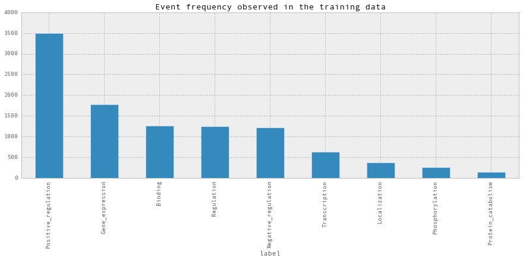

```python
pylab.rcParams['figure.figsize'] = 15, 5

apl = df.groupby(['label'])['count'].sum()
plt.title("Event frequency observed in the training data")
apl.order(ascending = False).plot(kind='bar')
plt.show()
```

Note that this does not mean there were 3500 `Positive_regulation` events, but rather that 3500 argument paths for `Positive_regulation` events were extracted from the training data.

## Average path length per category

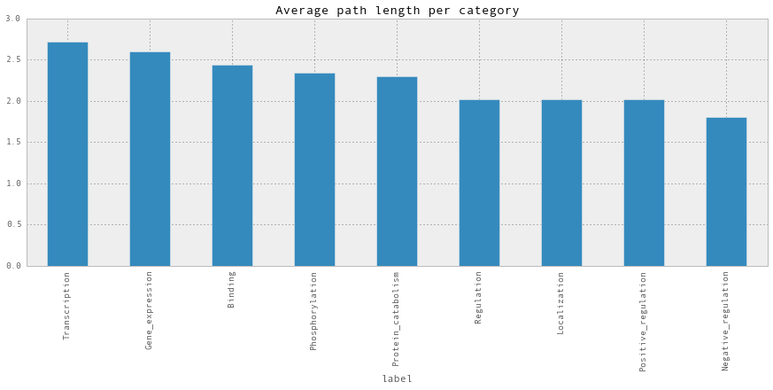

```python
pylab.rcParams['figure.figsize'] = 15, 5

apl = df.groupby(['label'])['path_length'].mean()
plt.title("Average path length per category")
apl.order(ascending = False).plot(kind='bar')
plt.show()
```

The above figure depicts the average number of *hops* from a given trigger for each event type.

## Trigger tag frequency (based on first token of trigger)

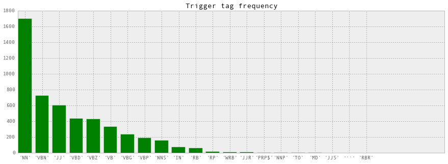

```python
from collections import Counter
pylab.rcParams['figure.figsize'] = 15, 5
# Count first tag in trigger
ttc = Counter(t[0] for t in df["trigger_tags"].str.split(' '))
tags, counts = zip(*ttc.most_common())
indices = np.arange(len(tags))
width = 0.7
plt.title("Trigger tag frequency")
plt.bar(indices, counts, color='g')
plt.xticks(indices + width * .6, tags)
plt.show()
```

## Bibliography

```
@inproceedings{Valenzuela+:2015aa,
  author    = {Valenzuela-Esc\'{a}rcega, Marco A. and Gustave Hahn-Powell and Thomas Hicks and Mihai Surdeanu},
  title     = {A Domain-independent Rule-based Framework for Event Extraction},
  organization = {ACL-IJCNLP 2015},
  booktitle = {Proceedings of the 53rd Annual Meeting of the Association for Computational Linguistics and the 7th International Joint Conference on Natural Language Processing of the Asian Federation of Natural Language Processing: Software Demonstrations (ACL-IJCNLP)},
  url = {http://www.aclweb.org/anthology/P/P15/P15-4022.pdf},
  year      = {2015},
  pages = {127--132},
  Note = {Paper available at \url{http://www.aclweb.org/anthology/P/P15/P15-4022.pdf}},
}
```